# 03-discrete-probability-calculations

Yasi Wang

9/7/2019

[figure not shown]

In this blog, I’d like to talk about **discrete probability calculations**, using the World Series game as an example.

# 1. Introduction

### a. World Series

**The World Series** is a best-of-7 match-up between the champions of the American and National Leagues of Major League Baseball. The rule is two team plays the game until one team has 4 wins. It means if one team wins 4 round, the game will end immediately and this team will be the champion of the game. The possible results are as follows:

|  | Round 1 | Round 2 | Round 3 | Round 4 | Round 5 | Round 6 | Round 7 |
| --- | --- | --- | --- | --- | --- | --- | --- |
| Result 1 | W | W | W | W |  |  |  |
| Result 2 | W | W | L | W | W |  |  |
| Result 3 | L | W | W | L | W | W |  |
| Result 4 | W | L | L | L | W | W | W |

### b. Negative Binomial Distribution

**The negative binomial distribution** is a discrete probability distribution of the number of successes in a sequence of independent and identically distributed Bernoulli trials before a specified (non-random) number of failures (denoted r) occurs. For example, if we define a 1 as failure, all non-1s as successes, and we throw a die repeatedly until 1 appears the third time (r = three failures), then the probability distribution of the number of non-1s that appeared will be a negative binomial distribution.

More generally, we define that the probability of success in each trial is p and of failure is (1 - p). We are observing this sequence until a predefined number r of failures have occurred. Then the random number of successes we have seen, X, will have the negative binomial (or Pascal) distribution:

$$X\sim\ NB(r,p)$$

(from Wikipedia)

### c. Bayes’ theorem

**Bayes’ theorem** describes the probability of an event, based on prior knowledge of conditions that might be related to the event. For example, if cancer is related to age, then, using Bayes’ theorem, a person’s age can be used to more accurately assess the probability that he has cancer than can be done without knowledge of the person’s age.

Bayes’ theorem is stated mathematically as the following equation:

$$P(A | B)=\frac{P(B | A)P(A)}{P(B)} = \frac{P(B | A)P(A)}{P(B | A)P(A) + P(B | \neg A)P(
\neg A)}$$

# 2. Simulation 1 (best-of-7 match-up)

### a. $P$ (Braves win World Series | $P_B$=0.55)

Now let’s see an example.

Setup:

– Suppose that the Braves and the Yankees are teams competing in the World Series.

– Suppose that in any given game, the probability that the Braves win is $P_B = 0.55$ and the probability that the Yankees win is $P_Y =1 - P_B = 0.45$.

There are two ways to approach the answer.

1. The function belows calculates the probability that the one team win the series of the game. (p = probability of winnings in each round, N = The maximum length of the game)

```r
win_prob <- function(N, p) {
  p_win <- p
  p_lose <- 1 - p
  num_win <- (N+1)/2
  total_win = 0
  for (i in (num_win:N)) {
    total_win <- choose(i - 1, num_win - 1)*p_win^(num_win)*p_lose^(i-num_win) + total_win
  }
  return(total_win)
}
```

2. The second way is to use the built-in function in R that calculate the negative binomial probability. The code means that the probability of 3 or fewer loses before 4th wins of the team Braves.

```r
win_prob(7,0.55)
```

```
## [1] 0.6082878
```

```r
#dnbinom(0,4,0.55) + dnbinom(1,4,0.55)+ dnbinom(2,4,0.55)+ dnbinom(3,4,0.55)
pnbinom(3,4,.55)
```

```
## [1] 0.6082878
```

Thus, $P$ (Braves win World Series | $P_B$ $=$ 0.55) = 0.608

### b. $P$ (Braves win World Series | $P_B = x$)

what if the probability that the Braves win in each round is $P_B = x$? Setting x from 0.5 to 1, I demonstrated a graph using plot() as follows. It shows that with x increases, the probability that Braves wins the World Series will also increases.

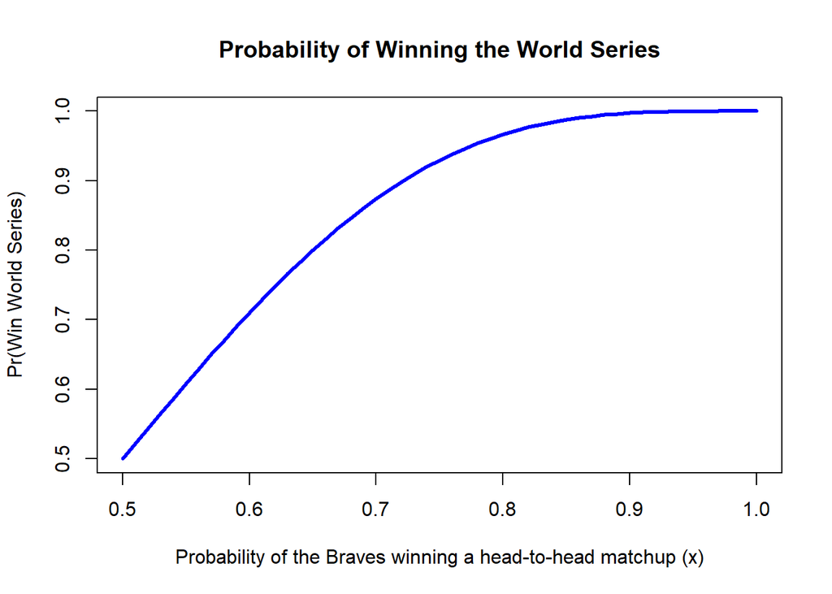

```r
win_final <- rep(NA, 51)
prob <- seq(0.5,1,0.01)

for (i in seq_along(prob)) {
  win_final[i] <- win_prob(7,prob[i])
}

plot(x = prob, y = win_final, type = "l", main = "Probability of Winning the World Series", xlab = "Probability of the Braves winning a head-to-head matchup (x)", ylab = "Pr(Win World Series)", pch=16, lwd = 3, col = "blue")
```

# 3. Simulation 2 (best-of-X Series)

### a. $P$ (Braves win World Series| $P_B$ $=$ 0.55) $\ge$ 0.8

Let’s think about more complex situation. Suppose we can change the World Series to be best-of-9 or some other best-of-X series, and we want to know the shortest series length N which can make $P$ (Braves win World Series| $P_B$ $=$ 0.55) $\ge$ 0.8. What is the relationship between X and N? Note: we assume that X should be odd to ensure that at least one team will win the series of game.

If we calculate by hand, it would be really really hard. But now we can use code! Now we start to set N = 1. Obviously N = 1 cannot guarantee $P$ (Braves win World Series| $P_B$ $=$ 0.55) $\ge$ 0.8. So we set N = N + 2. Doing the while loop, we finally get the result. That is, to ensure $P$ (Braves win World Series| $P_B$ $=$ 0.55) $\ge$ 0.8, the shortest series length N should be 71.

```r
# Q3
N = 1
while (N > 0) {
  if (win_prob(N, 0.55) >= 0.8) {
    break
  }
  N <- N + 2
}
N
```

```
## [1] 71
```

### b. $P$ (Braves win World Series| $P_B = x$) $\ge$ 0.8

If we set the probability that the Braves win in each round is $P_B = x$, the shortest series length should change correspondingly. The graph below displays that there is a sharp decline between 0.51~0.55.

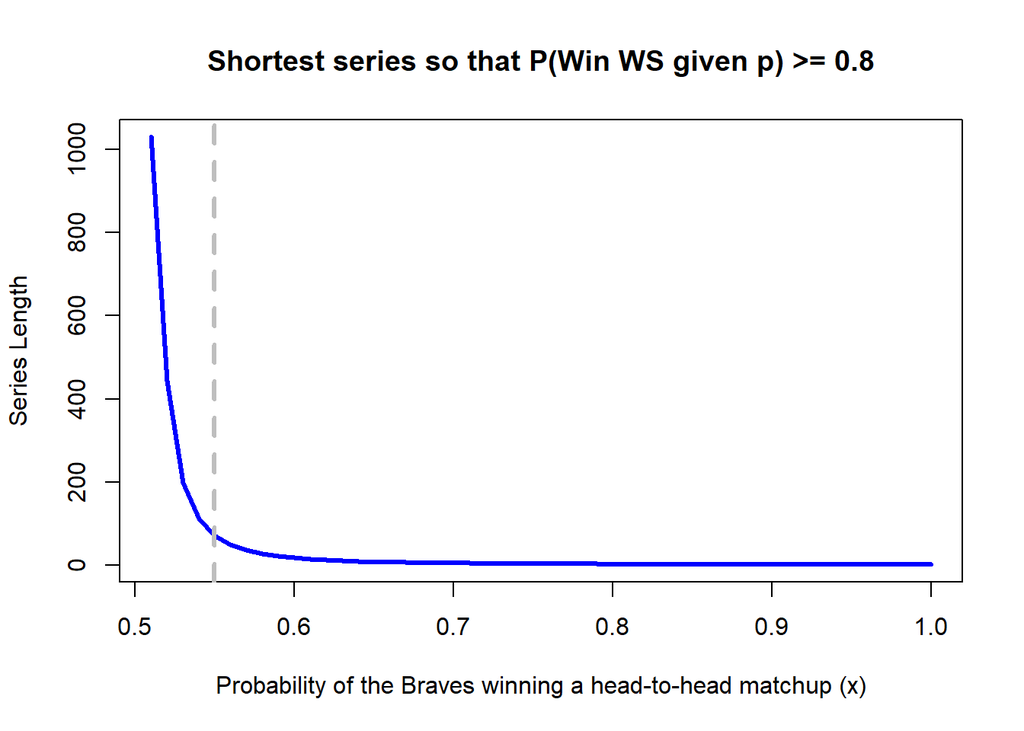

```r
# Q4
res <- rep(NA, 50)
prob <- seq(0.51,1,0.01)
win_final <- rep(NA, 50)


for (i in seq_along(prob)) {
  N <- 1
  while (N > 0) {
    tmp <- win_prob(N, prob[i])
    if (tmp >= 0.8) {
      res[i] <- N
      break
    }
    N = N + 2
  }
}

plot(x = prob, y = res, main = "Shortest series so that P(Win WS given p) >= 0.8", xlab = "Probability of the Braves winning a head-to-head matchup (x)", ylab = "Series Length", type = "l", pch=16, lwd = 3, col = "blue")
abline(v = 0.55, col = "gray", lwd=3, lty=2)
```

```r
# df <- data.frame(prob, res)
```

# 4. Simulation 3 (Bayesian probability)

### a. $P$ ($P_B$ $=$ 0.55 | Braves win World Series in 7 games)

If we want to calculate $P$ ($P_B$ $=$ 0.55 | Braves win World Series in 7 games), under the assumption that either $P_B=0.55$ or $P_B=0.45$, we can use **Bayes’ theorem** to solve the problem. The equation is:

$P(A | B)= \frac{P(B | A)P(A)}{P(B)} = \frac{P(B | A)P(A)}{P(B | A)P(A) + P(B | \neg A)P( \neg A)} = \frac {0.167 \times 0.5} { 0.167 \times 0.5 + 0.134 \times 0.5} = 0.55$

$P_A = P_{(P_B = 0.55})$ = 0.5

$P_{(B | A)}$ = 0.167

$P_{(\neg A)}$ = 1 - $P_A$ = 0.5

$P_{(B | \neg A)}$ = 0.134

```r
P_1 <- dnbinom(3, 4, 0.55)
P_2 <- dnbinom(3, 4, 0.45)

result <- 0.5 * dnbinom(3, 4, 0.55) / (0.5 * dnbinom(3, 4, 0.55) + 0.5 *dnbinom(3, 4, 0.45))
result
```

```
## [1] 0.55
```

# 5. Limitations and Conclusions

There are a few limitations of the calculation in our simulation. $P_B$ is always very hard to get. We even have to collect thousands of data to get this single probability.

Moreover, probability is only probability. But in the real-world competition, the results will be influenced by many factors. We can not only believe the theoretical winning probability, but also combine some other factors like the weather, players’ physical and psychological conditions.

Bernoulli distribution and negative Bernoulli distribution are very important concepts in discrete probability distribution. Many real- world phenomenons are related them. Having the insight of discrete probability can help us better understand and be adapted to the life.